# Ciclo menstrual: Clasificación de las fases mediante Deep Learning

MODELOS DE DEEP LEARNING

**Integrantes:**  
Sofía Roca Contreras  
Bianca Bruna Ramírez

**Profesor:**  
Francisco Plaza-Vega

Universidad de Santiago de Chile

# Introducción

## ¿Qué es el ciclo menstrual?

El ciclo menstrual [1] es un proceso biológico continuo que se define anatómica y endocrinológicamente a través de una secuencia cíclica de 4 fases:

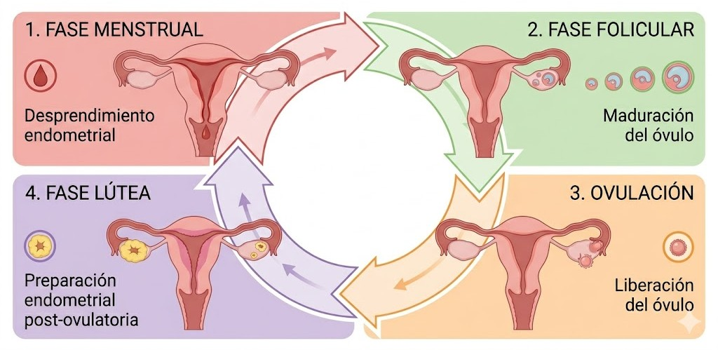

Figure 1: Fases ciclo menstrual

- **Fase menstrual:** Es la etapa inicial, donde ocurre el desprendimiento y expulsión del tejido endometrial. Hay una baja en los niveles de estrógeno y progesterona.
- **Fase folicular:** Los niveles de estrógeno aumentan lo que impulsa la reconstrucción del revestimiento uterino y la maduración de lo folículos ováricos.
- **Ovulación:** Se alcanza el punto máximo en los niveles de estrógeno y existe aumento repentino de la hormona luteinizante (LH) lo que desencadena la liberación del óvulo.
- **Fase lútea:** Después de la ovulación, el foliculo vacio se transforma en cuerpo lúteo, secretando progresterona para densificar el endometrio.

## Ciclos regulares e irregulares

**Ciclo regular**: La duración habitual es de 24 a 38 días y la variación entre el ciclo más corto y el más largo de la misma persona es menor a 7 - 9 días.

**Ciclo irregular**: Es cuando se cumple una de esas condiciones:

- Es más corto de 24 días (Polimenorrea).
- Es más largo de 38 días (Oligomenorrea).
- La variación entre el ciclo más largo y el más corto es mayor a 9 días en un periodo de 6 meses.

Variación ciclo = Ciclo más largo - Ciclo más corto [2]

# Planteamiento del problema

## Planteamiento del problema

**Problema:** Los métodos manuales y calendarios asumen ciclos estáticos y regulares. Estos fallan ante alteraciones por estrés, estilo de vida o diagnósticos médicos; además, son propensos al error humano.

También tenemos un desafío computacional, ya que los historiales menstruales conforman series temporales ruidosas, incompletas y con dependencias complejas a largo plazo.

Por lo que los algoritmos lineales clásicos son incapaces de procesar y capturar esta variabilidad de manera efectiva.

**Solución:** Desarrollar arquitecturas avanzadas de Deep Learning que procesen secuencias temporales y biomarcadores fisiológicos para clasificar las fases en ciclos regulares e irregulares.

## Justificación

Algunas de las dimensiones que más se ven impactadas al desarrollar un buen modelo de clasificación son:

- **Salud Reproductiva y Planificación Familiar:** Permite a las parejas planificar o evitar embarazos de manera natural, reduciendo los riesgos de salud o económicos.
- **Manejo Personalizado de Síntomas:** Ayuda a gestionar ciertos síntomas como la fatiga, cambios de humor, calambres, etc.
- **Intervenciones Nutricionales y de Estilo de Vida:** La clasificación de la fase habilita la creación de recomendaciones dietéticas personalizadas, ya que los requerimientos nutricionales varían según la etapa del ciclo.
- **Cierre de la Brecha Tecnológica y Educativa:** Implementar soluciones basadas en IA no solo provee predicciones clínicas, sino que ofrece a las mujeres un espacio confidencial y educativo para gestionar su salud de manera proactiva.

# Estado del Arte

## Modelado de Series Temporales

| Modelo | Precisión | Adaptabilidad |
| --- | --- | --- |
| **LSTM** [3] | **90% – 91.3%** | Excelente. Modela ciclos irregulares. |
| **CNN 1D** | **88.9%** | Buena: Identifica patrones clave, pero es inferior a LSTM en secuencias largas. |
| **ML Clásico** [4] | **78% – 85.2%** | Baja. Falla ante ciclos irregulares. |

Por lo tanto, las redes **LSTM** dominan la clasificación de las fases del ciclo menstrual, debido a su capacidad para capturar dependencias temporales y patrones históricos complejos. En cambio, el modelo clásico presenta dificultades para mantener la consistencia temporal en ciclos irregulares.

## Biomarcadores Fisiológicos

| Biomarcador | Modelo Aplicado | Objetivo Clínico | Resultado |
| --- | --- | --- | --- |
| **Temperatura Corporal Basal (BBT)** | Red LSTM | Identificar la ventana de ovulación. | ~95% de precisión minimizando el Error Absoluto Medio (MAE). |
| **Temperatura Piel Abdominal (AST)** [5] | LSTM Bidireccional + CPD(Cumulative Probability Distribution). | Clasificar con éxito las fases: folicular, ovulatoria y lútea | Mejora notable en la detección de fases complejas, elevando significativamente el *F-measure.* |

El uso de biometría continua mediante sensores portátiles ha permitido identificar fases del ciclo menstrual con una precisión cercana al nivel clínico.

## Arquitecturas de Vanguardia

| Enfoque | Algoritmos | Aplicación | Impacto |
| --- | --- | --- | --- |
| **Nutrición** [6] | Transformers | Identificar fases a partir de síntomas y recomendar dietas personalizadas. | **96% precisión** al procesar datos de síntomas para recomendaciones nutricionales |
| **Prevención de Riesgos** [7] | Ecosistemas Multimodelo (Random Forest) | Evalúa síntomas para alertar sobre condiciones (como el SOP o dismenorrea) y pronostica síntomas diarios. | 73% de exactitud en síntomas de alerta y 82% al pronosticar síntomas. |
| **Sistemas híbridos** [8] | Reglas Matemáticas + LSTM | Corregir ciclos anómalos con biometría. | Menor MSE y alta precisión temporal. |

En general, la tendencia actual es combinar múltiples modelos de inteligencia artificial para construir sistemas más precisos, personalizados y adaptativos.

# Hipótesis y objetivos

## Hipótesis

La implementación de una arquitectura de Deep Learning basada en redes recurrentes (LSTM) bajo un enfoque secuencial *Many-to-One*, superará significativamente el desempeño de los modelos de referencia simples (modelo bases o calendarios estáticos) en la clasificación de la fase del ciclo menstrual. Esta arquitectura será capaz de capturar las dependencias temporales a largo plazo y extraer relaciones ocultas en ciclos irregulares y ruidosos, donde los algoritmos tradicionales fallan.

## Objetivos

**Objetivo general:** Proponer y diseñar una arquitectura de Deep Learning ideal para el procesamiento de series temporales fisiológicas, con el fin de clasificar la fase biológica del ciclo menstrual en usuarias con patrones regulares e irregulares.

**Objetivos específicos:**

- Modelar el problema como una tarea de clasificación de secuencias temporales mediante un enfoque Many-to-One (Muchos a Uno).
- Preprocesar la base de datos mediante técnicas de imputación que mantengan la estructura y la dependencia temporal de los registros con valores faltantes.
- Diseñar una arquitectura de Deep Learning que integre memoria a largo plazo (como las LSTM) para procesar la naturaleza secuencial de los historiales menstruales.
- Configurar un entrenamiento robusto que incorpore técnicas de regularización, como la *Early Stopping*, para prevenir el sobreajuste.
- Establecer un marco de evaluación que compare el desempeño de la red neuronal contra modelos de referencia utilizando métricas para clasificación, como la matriz de confusión y F1-Score.

# Metodología preliminar

# Base de datos

**Base de datos** de 80 variables y 1.665 observaciones extraída de [Kaggle](https://www.kaggle.com/datasets/nikitabisht/menstrual-cycle-data)

Registros de ciclos menstruales de 159 personas.

| Variables | Descripción | Tipo |
| --- | --- | --- |
| id | Identificador único de la usuaria | Texto |
| numero_ciclo | Número secuencial del ciclo registrado para esa usuaria | Entero |
| edad | Edad de la usuaria | Entero |
| imc | Índice de Masa Corporal (IMC) | Decimal |
| duracion_ciclo | Duración total del ciclo en días. | Entero |
| promedio_duracion_ciclo | Promedio de duración de los ciclos de la usuaria | Entero |
| duracion_menstruacion | Duración del periodo menstrual (días de sangrado) | Entero |
| promedio_duracion_menstruacion | Promedio de duración de la menstruación | Decimal |
| intensidad_sangrado_media | Intensidad promedio de sangrado | Decimal |
| primer_dia_alta_fertilidad | Primer día de niveles “altos” de fertilidad detectados | Entero |
| total_dias_alta_fertilidad | Cantidad total de días con fertilidad alta | Entero |
| total_dias_peak_fertilidad | Cantidad de días en el nivel máximo (Peak) de fertilidad | Entero |
| dia_estimado_ovulacion | Día estimado de la ovulación dentro del ciclo | Entero |
| duracion_fase_lutea | Duración de la fase lútea (post-ovulación) | Entero |

## Visualización

Visualización de las primeras 5 observaciones de la base de datos.

| id | numero_ciclo | edad | imc | duracion_ciclo | promedio_duracion_ciclo | duracion_menstruacion | promedio_duracion_menstruacion | intensidad_sangrado_media | primer_dia_alta_fertilidad | total_dias_alta_fertilidad | total_dias_peak_fertilidad | dia_estimado_ovulacion | duracion_fase_lutea |
| --- | --- | --- | --- | --- | --- | --- | --- | --- | --- | --- | --- | --- | --- |
| nfp8122 | 1 | 36 | 21.25472 | 29 | 27.33 | 5 | 4.49 | 9.04 | 12 | 5 | 2 | 17 | 12 |
| nfp8122 | 2 | NA | NA | 27 | NA | 5 | NA | NA | 13 | 2 | 2 | 15 | 12 |
| nfp8122 | 3 | NA | NA | 29 | NA | 5 | NA | NA | NA | 1 | 2 | 15 | 14 |
| nfp8122 | 4 | NA | NA | 27 | NA | 5 | NA | NA | 13 | 2 | 2 | 15 | 12 |
| nfp8122 | 5 | NA | NA | 28 | NA | 5 | NA | NA | 12 | 4 | 2 | 16 | 12 |

Selecciona el ID de la usuaria:

[interactive chart not shown]

## Metodología

- **Fase 1**: Definición del problema.
  - Enfoque del problema.
  - Aquitectura objetivo. [9]
- **Fase 2**: Preprocesamiento de datos.
  - Limpieza e imputación.
- **Fase 3**: Arquitectura de modelos.
  - 1D-CNN.
  - LSTM.
- **Fase 4**: Entrenamiento.
  - Función de coste.
  - Optimización.
  - Prevención del sobreajuste. [9]
- **Fase 5**: Evaluación y modelos de referencia.
  - Modelos bases. [9]
  - Métricas.

# Conclusión

## Conclusión

- Se evidencia que los métodos tradicionales son insuficientes para abordar la naturaleza variable del ciclo menstrual.
- Al formular el problema orientado a las secuencias temporables, la metodología de Deep Learning propuesta, nos entrega las herramientas exactas para resolverlo.
- La capacidad de una red como las LSTM para aprender representaciones a partir de datos ruidosos, sumada a un entrenamiento con validación estricta, nos asegura que estamos construyendo una solución computacionalmente robusta, y con un impacto directo en la monitorización de la salud reproductiva.

## Referencias

[1]

The Manual’s Editorial Staff, “Ciclo menstrual.” Manual MSD versión para público general, Apr. 2024. Available: https://www.msdmanuals.com/es/hogar/salud-femenina/biolog%C3%ADa-del-aparato-reproductor-femenino/ciclo-menstrual

[2]

M. G. Munro *et al.*, “The FIGO ovulatory disorders classification system,” *International Journal of Gynecology & Obstetrics*, 2022, doi: 10.1002/ijgo.14331.

[3]

M. Khairunisa, D. M. S. A. Putri, and I. G. N. L. Wijayakusuma, “Comparison of machine learning methods for menstrual cycle analysis and prediction,” *Journal of Applied Informatics and Computing*, vol. 9, no. 2, pp. 348–353, 2025.

[4]

H. Harshavardhan, N. Tendulkar, P. U. Shetty, R. P. Shetty, *et al.*, “AI-powered period tracker: Comparative analysis of machine learning and deep learning models for menstrual health prediction,” in *2025 international conference on emerging technologies and innovation for sustainability (EmergIN)*, IEEE, 2025, pp. 269–274.

[5]

Y. Murayama, A. Uemura, M. Kitazawa, J. Toyotani, A. Taniuchi, and T. Togawa, “Determination of biphasic menstrual cycle based on the fluctuation of abdominal skin temperature during sleep,” *Advanced Biomedical Engineering*, vol. 12, pp. 28–36, 2023.

[6]

E. Logapriya, R. Surendran, D. Poornima, and L. Kartheesan, “Optimized deep learning framework for personalized nutritional recommendations across the menstrual cycle,” in *2024 international conference on sustainable communication networks and application (ICSCNA)*, IEEE, 2024, pp. 1078–1084.

[7]

J. Gulati, D. Chila, S. Bhamare, S. Nadkarni, M. Retharekar, and S. Chila, “Menstrual health monitoring and prediction system using machine learning,” in *2026 twelfth international conference on bio signals, images, and instrumentation (ICBSII)*, IEEE, 2026, pp. 1–6.

[8]

C. Khadse and S. Mendhe, “A systematic approach to menstrual tracking: Proposed methodology and design,” in *2025 7th international conference on intelligent sustainable systems (ICISS)*, IEEE, 2025, pp. 1690–1699.

[9]

F. Plaza-Vega, “Material docente y diapositivas de clase: Modelos de deep learning (unidades 1–4).” Universidad de Santiago de Chile; Diapositivas de clase, Universidad de Santiago de Chile, 2025.